# Seal and Sea Lion Management Briefing

L. Pandori - Cabrillo National Monument

### Introduction

Cabrillo National Monument (CABR) is a unit of the National Park System located at the tip of Point Loma in San Diego, CA. Despite its small footprint (160 terrestrial acres), the monument attracts nearly one million visitors each year, 380,000 of which visited the coastal area of the park in 2020. Further, the *c.* 1 mile stretch of shoreline in the coastal area of the park is used by seals and sea lions. This results in potential conflicts between conservation of natural resources, visitors, and other users of the area. Due to its value as both a habitat refuge and public resource, it is critical to monitor use patterns by visitors, seals and sea lions at Cabrillo National Monument.

### Results

The average number of visitors per survey is higher at the Zone 1 Vista than at the Spur Trail Vista. Alternately, the average number of seals is higher at the Spur Trail Vista than the Zone 1 Vista. Only 2 sea lions were observed during 33 surveys conducted between June 2021 and February 2022. Since there were so few sightings, the following charts show only seal abundance over time and seal haul-out (land rest) site preference.

Average count per survey

[output not shown]

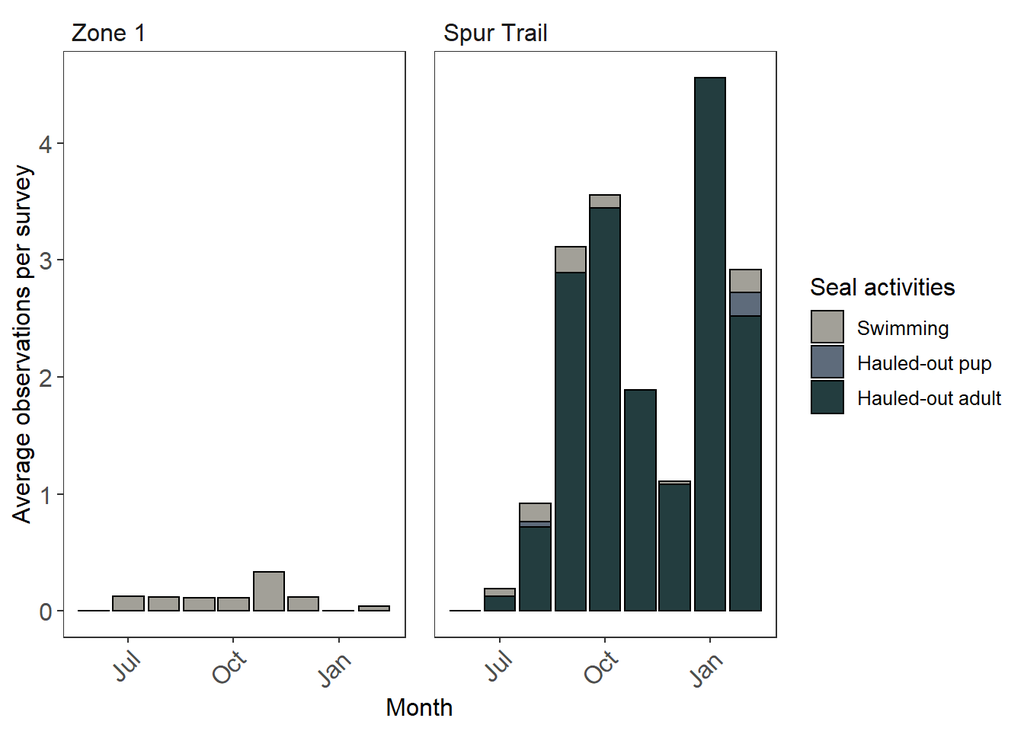

### Methods Overview

California sea lions (*Zalophus californianus*) and harbor seals (*Phoca vitulina*) are the focal species of this sampling due to their high abundances and frequent haul-out, or land resting, behavior along southern California shores (Antonelis & Fiscus 1980). Volunteers in Parks (VIPs) conduct 10 minute observations of the numbers of seals and sea lions visible from three overlooks along the coastal area of the park (Zone 1, Spur Trail and Lot 3 overlooks). After conducting seal and sea lion observations, volunteers conduct 10 minute observations of the number of humans in the intertidal area. They record the time, estimated percent cloud cover, and subjective wind level (on a scale of 0-3) during surveys. The time of survey events is used to get the tide level, air temperature and water temperature from the National Oceanographic and Atmospheric Administration (NOAA) station at Scripps Pier in La Jolla.